# Dhairya Kothari

## SVM with MNIST

#### Parts:

#### - (1) Exploring SVM

#### - (2) SVM with RBF kernel

#### - (3) SVM with Poly kernel

Describe how the multi-class classification is different for SVC and LinearSVC. Be explicit, don't just describe what's in the documentation. For example, what does 'one-against-one' and 'one-vs-the-rest' mean?

The one-against-one classifier trains binary classifer for N class (multi class) data set. Each classifier recieves a pair of classes from the training set and we learn to classify between these two labels/classes. On the other hand, One versus Rest approach, we train on classifier per class, with the samples from that class labelled as Postive class and the rest as Negative class, and repeating these N times gives us a N class classifier. Now, all the samples are given Weights (probablity) for each class and from them we choose a winner class, giving the final Label. In order to perform Multi class classification we need to transform into a set of binary classification problem. When it comes to multi class classification The main difference between SVC and LinearSVC is they use One Vs One and One Vs Rest approach. One clear difference in SVC and Linear SVC is: SVC offers us different Kernels (rbf or poly) while LinearSVC just produces a linear margin of seperation. While in SVC the max iterations are infinite, LinearSVC limits them to 1000.

#### The last major difference is, in LinearSVC we have an option to choose between dual form of SVM or single form. In SVC we do no have that option.

#### Importing the packages and data with Tensorflow

```python
from scipy.stats import mode
import numpy as np
#from mnist import MNIST
from time import time
import pandas as pd
import os
import matplotlib.pyplot as matplot
import matplotlib
%matplotlib inline

import random
matplot.rcdefaults()
from IPython.display import display, HTML
from itertools import chain
from sklearn.metrics import confusion_matrix
from sklearn.metrics import accuracy_score
import seaborn as sb
from sklearn.model_selection import ParameterGrid
from sklearn.svm import SVC, LinearSVC
import warnings
warnings.filterwarnings('ignore')
```

```python
from tensorflow.examples.tutorials.mnist import input_data
mnist = input_data.read_data_sets('MNIST_data/')
```

```
Extracting MNIST_data/train-images-idx3-ubyte.gz
Extracting MNIST_data/train-labels-idx1-ubyte.gz
Extracting MNIST_data/t10k-images-idx3-ubyte.gz
Extracting MNIST_data/t10k-labels-idx1-ubyte.gz
```

```python
train = mnist.train.images
validation = mnist.validation.images
test = mnist.test.images

trlab = mnist.train.labels
vallab = mnist.validation.labels
tslab = mnist.test.labels

train = np.concatenate((train, validation), axis=0)
trlab = np.concatenate((trlab, vallab), axis=0)
```

#### Imp thing to remember: Data is 0-1 normalized

We save a lot of compute time by keeping the data that way and we dont lose any significant amount of accuracy

### Linear SVC

Running a Sample Linear SVM classifier on default values to see how the model does on MNIST data

```python
svm = LinearSVC(dual=False)
svm.fit(train, trlab)
```

```
LinearSVC(C=1.0, class_weight=None, dual=False, fit_intercept=True,
     intercept_scaling=1, loss='squared_hinge', max_iter=1000,
     multi_class='ovr', penalty='l2', random_state=None, tol=0.0001,
     verbose=0)
```

```python
svm.coef_
svm.intercept_
```

```
array([-1.20849557, -0.1362278 , -0.81846194, -1.19352824, -0.50981085,
        0.03587096, -1.14999805, -0.24171445, -2.0858455 , -1.32422686])
```

```python
pred = svm.predict(test)
```

```python
accuracy_score(tslab, pred) # Accuracy
```

```
0.91820000000000002
```

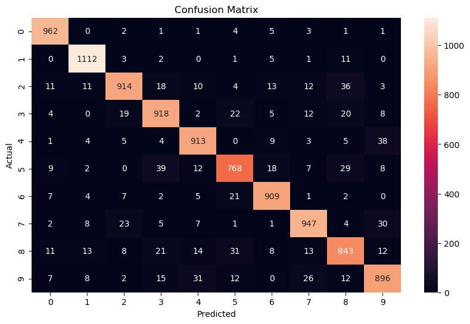

```python
cm = confusion_matrix(tslab, pred)
matplot.subplots(figsize=(10, 6))
sb.heatmap(cm, annot = True, fmt = 'g')
matplot.xlabel("Predicted")
matplot.ylabel("Actual")
matplot.title("Confusion Matrix")
matplot.show()
```

As we can see that the SVM does a pretty decent job at classifying, we still get the usual misclassification on 5-8, 2-8, 5-3, 4-9. However, accuracy of **91.82%** is good

## (i)

### Running Linear SVC for multiple cost factor(s) C

```python
acc = []
acc_tr = []
coefficient = []
for c in [0.0001,0.001,0.01,0.1,1,10,100,1000,10000]:
    svm = LinearSVC(dual=False, C=c)
    svm.fit(train, trlab)
    coef = svm.coef_

    p_tr = svm.predict(train)
    a_tr = accuracy_score(trlab, p_tr)

    pred = svm.predict(test)
    a = accuracy_score(tslab, pred)

    coefficient.append(coef)
    acc_tr.append(a_tr)
    acc.append(a)
```

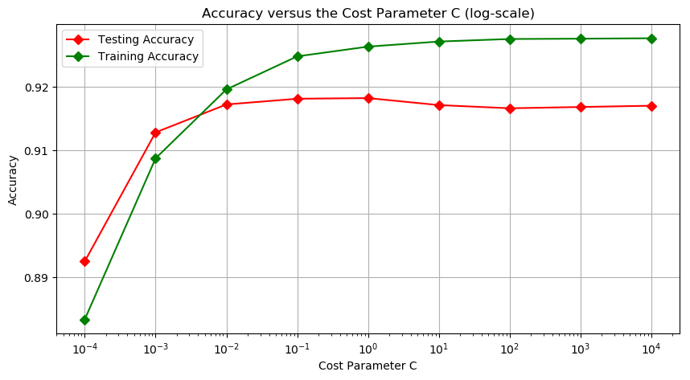

```python
c = [0.0001,0.001,0.01,0.1,1,10,100,1000,10000]

matplot.subplots(figsize=(10, 5))
matplot.semilogx(c, acc,'-gD' ,color='red' , label="Testing Accuracy")
matplot.semilogx(c, acc_tr,'-gD' , label="Training Accuracy")
#matplot.xticks(L,L)
matplot.grid(True)
matplot.xlabel("Cost Parameter C")
matplot.ylabel("Accuracy")
matplot.legend()
matplot.title('Accuracy versus the Cost Parameter C (log-scale)')
matplot.show()
```

We clearly see a bias variance trade off in the graph. As the cost increases, the Training accuracy increases, so as the test accuracy, but only till c=1, then we see over fitting. From, c=10 to 1000 we see the model overfitting and we see Low Bias and High Variance  
**So as we go from Left to Right: Bias Decreases and Variance Increases**

## (ii)

### We choose the model with best testing accuracy i.e. c = 1

```python
svm_coef = coefficient[4]
svm_coef.shape
```

```
(10, 784)
```

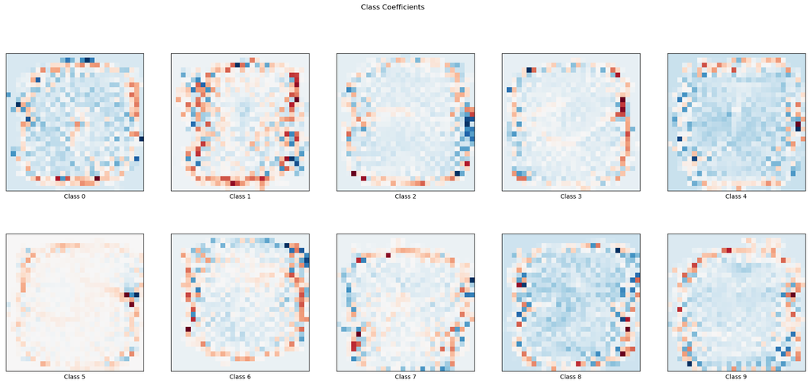

```python
matplot.subplots(2,5, figsize=(24,10))
for i in range(10):
    l1 = matplot.subplot(2, 5, i + 1)
    l1.imshow(svm_coef[i].reshape(28, 28), cmap=matplot.cm.RdBu)
    l1.set_xticks(())
    l1.set_yticks(())
    l1.set_xlabel('Class %i' % i)
matplot.suptitle('Class Coefficients')
matplot.show()
```

These images look nothing like the images we saw in Logistic regression or Naive Bayes. In Naive Bayes, the underlying number was clearly visible, while in Logistice regression the pattern seemed quite distinct between all the classes. However, here you dont see any apparant patterns or distinctness and really hard to differentiate.

## (iii)

### Linear SVC with Penalty: l1

```python
acc = []
acc_tr = []
coefficient = []
for c in [0.0001,0.001,0.01,0.1,1,10,100,1000,10000]:
    svm = LinearSVC(dual=False, C=c, penalty='l1')
    svm.fit(train, trlab)
    coef = svm.coef_

    p_tr = svm.predict(train)
    a_tr = accuracy_score(trlab, p_tr)

    pred = svm.predict(test)
    a = accuracy_score(tslab, pred)

    coefficient.append(coef)
    acc_tr.append(a_tr)
    acc.append(a)
```

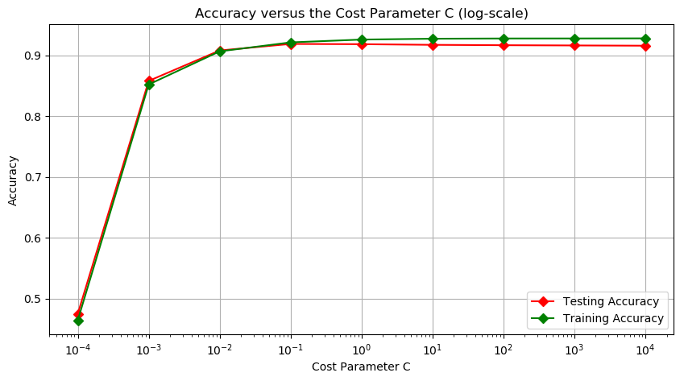

```python
c = [0.0001,0.001,0.01,0.1,1,10,100,1000,10000]

matplot.subplots(figsize=(10, 5))
matplot.semilogx(c, acc,'-gD' ,color='red' , label="Testing Accuracy")
matplot.semilogx(c, acc_tr,'-gD' , label="Training Accuracy")
#matplot.xticks(L,L)
matplot.grid(True)
matplot.xlabel("Cost Parameter C")
matplot.ylabel("Accuracy")
matplot.legend()
matplot.title('Accuracy versus the Cost Parameter C (log-scale)')
matplot.show()
```

Exact same thing with just a slight difference is clearly observed here as well. We see a bias variance trade off in the graph. As the cost increases, the Training accuracy increases, so as the test accuracy, but only till c=1, then we see over fitting. From, c=10 to 1000 we see the model overfitting and we see Low Bias and High Variance. Only thing is with L1 Penalty we have a lesser effect of overfitting and the model performs really poorly with lesser cost values.  
**Again, as we go from Left to Right: Bias Decreases and Variance Increases**

### Once more, we choose the model with best testing accuracy i.e. c = 1

```python
svm_coef = coefficient[4]
svm_coef.shape
```

```
(10, 784)
```

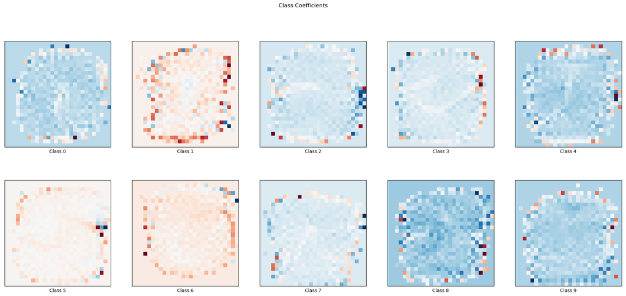

```python
matplot.subplots(2,5, figsize=(24,10))
for i in range(10):
    l1 = matplot.subplot(2, 5, i + 1)
    l1.imshow(svm_coef[i].reshape(28, 28), cmap=matplot.cm.RdBu)
    l1.set_xticks(())
    l1.set_yticks(())
    l1.set_xlabel('Class %i' % i)
matplot.suptitle('Class Coefficients')
matplot.show()
```

It reflects my views on Linear SVC with L2 (default) penalty, these images look very vaguely like the original images, also different than we saw in Logistic regression or Naive Bayes. In Naive Bayes, the underlying number was clearly visible, while in Logistice regression the pattern seemed quite distinct between all the classes. However, here you dont see any apparant patterns or distinctness and hard to differentiate between classes. However, we can also interpret some numbers like 0,5,6,8

Another important observation is, the images are also different looking than its L2 siblings as well, not by a bigger margin, but still different none the less.

### SVC RBF kernel

```python
from scipy.stats import mode
import numpy as np
from time import time
import pandas as pd
import os
import matplotlib.pyplot as matplot
import matplotlib
%matplotlib inline

import random
matplot.rcdefaults()
from IPython.display import display, HTML
from itertools import chain
from sklearn.metrics import confusion_matrix
from sklearn.metrics import accuracy_score
import seaborn as sb
from sklearn.model_selection import ParameterGrid
from sklearn.svm import SVC, LinearSVC
import warnings
warnings.filterwarnings('ignore')
```

```python
from tensorflow.examples.tutorials.mnist import input_data
mnist = input_data.read_data_sets('MNIST_data/')
```

```
Extracting MNIST_data/train-images-idx3-ubyte.gz
Extracting MNIST_data/train-labels-idx1-ubyte.gz
Extracting MNIST_data/t10k-images-idx3-ubyte.gz
Extracting MNIST_data/t10k-labels-idx1-ubyte.gz
```

```python
train = mnist.train.images
validation = mnist.validation.images
test = mnist.test.images

trlab = mnist.train.labels
vallab = mnist.validation.labels
tslab = mnist.test.labels

train = np.concatenate((train, validation), axis=0)
trlab = np.concatenate((trlab, vallab), axis=0)
```

### We generate a random sample of the data and check how the distribution is compared to the original distribution

We choose sampling as running these many models would increase the time complexity as well. SO keeping time constraint in mind I sample 10% of the data.

```python
#generating a random sequence for sampling
seq = np.random.randint(0,60000,6000)
train_samp = train[seq]
trlab_samp = trlab[seq]

train_samp.shape
trlab_samp.shape
```

```
(6000,)
```

```python
seq = np.random.randint(0,10000,1000)
test_samp = test[seq]
tslab_samp = tslab[seq]

test_samp.shape
tslab_samp.shape
```

```
(1000,)
```

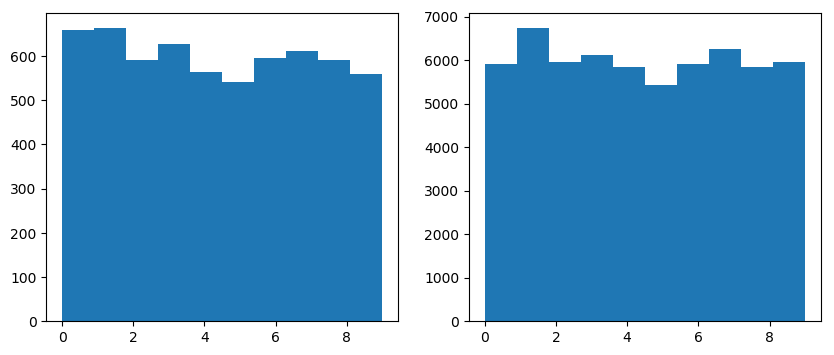

```python
fig, ax = matplot.subplots(1,2, figsize=(10,4))
ax[0].hist(trlab_samp)
ax[1].hist(trlab)
fig.show
matplot.show()
```

## (i)

### Running SVC for multiple cost factor(s) C and Gamma

```python
coefficient = []
n_supp = []
sup_vec = []
i = 0
df = pd.DataFrame(columns = ['c','gamma','train_acc','test_acc'])
for c in [0.01, 0.1, 1, 10, 100]:
    for g in [0.01, 0.1, 1, 10, 100]:
        svm = SVC(kernel='rbf', C=c, gamma=g)
        model = svm.fit(train_samp, trlab_samp)
        globals()['model%s' % i] = model
        d_coef = svm.dual_coef_
        support = svm.n_support_
        sv = svm.support_

        p_tr = svm.predict(train_samp)
        a_tr = accuracy_score(trlab_samp, p_tr)

        pred = svm.predict(test_samp)
        a = accuracy_score(tslab_samp, pred)

        coefficient.append(d_coef)
        n_supp.append(support)
        sup_vec.append(sv)
        df.loc[i] = [c,g,a_tr,a]
        i=i+1
```

```python
df
```

|  | c | gamma | train_acc | test_acc |
| --- | --- | --- | --- | --- |
| 0 | 0.01 | 0.01 | 0.644333 | 0.657 |
| 1 | 0.01 | 0.10 | 0.110500 | 0.133 |
| 2 | 0.01 | 1.00 | 0.110500 | 0.133 |
| 3 | 0.01 | 10.00 | 0.110500 | 0.133 |
| 4 | 0.01 | 100.00 | 0.110500 | 0.133 |
| 5 | 0.10 | 0.01 | 0.918833 | 0.911 |
| 6 | 0.10 | 0.10 | 0.229500 | 0.231 |
| 7 | 0.10 | 1.00 | 0.110500 | 0.133 |
| 8 | 0.10 | 10.00 | 0.110500 | 0.133 |
| 9 | 0.10 | 100.00 | 0.110500 | 0.133 |
| 10 | 1.00 | 0.01 | 0.977167 | 0.951 |
| 11 | 1.00 | 0.10 | 1.000000 | 0.868 |
| 12 | 1.00 | 1.00 | 1.000000 | 0.157 |
| 13 | 1.00 | 10.00 | 1.000000 | 0.133 |
| 14 | 1.00 | 100.00 | 1.000000 | 0.133 |
| 15 | 10.00 | 0.01 | 1.000000 | 0.964 |
| 16 | 10.00 | 0.10 | 1.000000 | 0.877 |
| 17 | 10.00 | 1.00 | 1.000000 | 0.160 |
| 18 | 10.00 | 10.00 | 1.000000 | 0.133 |
| 19 | 10.00 | 100.00 | 1.000000 | 0.133 |
| 20 | 100.00 | 0.01 | 1.000000 | 0.964 |
| 21 | 100.00 | 0.10 | 1.000000 | 0.877 |
| 22 | 100.00 | 1.00 | 1.000000 | 0.160 |
| 23 | 100.00 | 10.00 | 1.000000 | 0.133 |
| 24 | 100.00 | 100.00 | 1.000000 | 0.133 |

## (ii)

### We choose C=10 and Gamma=0.01 to look at the Support vectors

```python
pd.DataFrame(coefficient[15]) # dual_coef_
```

|  | 0 | 1 | 2 | 3 | 4 | 5 | 6 | 7 | 8 | 9 | ... | 2467 | 2468 | 2469 | 2470 | 2471 | 2472 | 2473 | 2474 | 2475 | 2476 |
| --- | --- | --- | --- | --- | --- | --- | --- | --- | --- | --- | --- | --- | --- | --- | --- | --- | --- | --- | --- | --- | --- |
| 0 | 0.000000 | 0.000000 | 0.00000 | 0.000000 | 0.00000 | 1.233223 | 0.463437 | 0.000000 | 0.000000 | 0.00000 | ... | -0.000000 | -0.000000 | -0.000000 | -0.665725 | -0.000000 | -0.000000 | -0.979185 | -0.000000 | -0.651719 | -0.286580 |
| 1 | 0.733241 | 0.338779 | 0.00000 | 0.000000 | 0.00000 | 1.599885 | 0.847806 | 0.000000 | 0.148967 | 0.00000 | ... | -0.000000 | -0.000000 | -0.000000 | -2.656140 | -0.000000 | -0.000000 | -0.000000 | -0.885662 | -0.000000 | -0.318750 |
| 2 | 0.000000 | 0.000000 | 0.16819 | 0.000000 | 0.00000 | 1.332503 | 1.047378 | 0.000000 | 0.124441 | 0.00000 | ... | -0.500293 | -0.000000 | -0.000000 | -1.489073 | -0.000000 | -0.000000 | -0.000000 | -0.464601 | -0.450088 | -0.182432 |
| 3 | 0.000000 | 0.000000 | 0.00000 | 0.000000 | 0.00000 | 3.575345 | 0.498475 | 0.000000 | 0.188376 | 0.00000 | ... | -0.000000 | -0.000000 | -0.000000 | -3.857057 | -0.000000 | -0.000000 | -1.831419 | -0.000000 | -0.000000 | -3.918929 |
| 4 | 0.000000 | 0.000000 | 0.00000 | 0.000000 | 0.00000 | 2.451250 | 2.909456 | 0.000000 | 0.788204 | 0.03408 | ... | -0.000000 | -0.000000 | -0.435685 | -0.000000 | -2.925009 | -1.568582 | -0.503543 | -2.701709 | -0.000000 | -0.974694 |
| 5 | 0.000000 | 0.000000 | 0.00000 | 0.000000 | 0.00000 | 3.574567 | 0.000000 | 0.000000 | 0.000000 | 0.00000 | ... | -0.000000 | -0.000000 | -0.000000 | -1.288726 | -0.000000 | -0.000000 | -4.472535 | -0.038601 | -0.000000 | -2.727674 |
| 6 | 0.000000 | 0.000000 | 0.00000 | 0.000000 | 0.00000 | 2.472752 | 1.138073 | 0.000000 | 0.000000 | 0.00000 | ... | -0.000000 | -0.000000 | -0.000000 | -0.782389 | -0.000000 | -0.000000 | -1.677264 | -0.057191 | -0.000000 | -0.000000 |
| 7 | 0.000000 | 0.000000 | 0.00000 | 0.425428 | 0.90783 | 0.350570 | 0.944754 | 0.000000 | 0.000000 | 0.00000 | ... | -0.107843 | -7.508478 | -0.000000 | -1.582007 | -0.000000 | -0.000000 | -0.000000 | -1.648960 | -0.000000 | -0.000000 |
| 8 | 0.000000 | 0.000000 | 0.00000 | 0.000000 | 0.00000 | 2.271634 | 0.520486 | 0.290487 | 0.000000 | 0.00000 | ... | -0.821034 | -0.000000 | -0.000000 | -5.498512 | -0.000000 | -0.000000 | -3.585487 | -0.217215 | -0.656942 | -2.623120 |

9 rows × 2477 columns

```python
pd.DataFrame(n_supp[15]) # n_support_
```

|  | 0 |
| --- | --- |
| 0 | 180 |
| 1 | 144 |
| 2 | 270 |
| 3 | 274 |
| 4 | 277 |
| 5 | 303 |
| 6 | 220 |
| 7 | 212 |
| 8 | 312 |
| 9 | 285 |

"n*support*" divides the number of support vestors by the class. So we can say that when class 0 has 180 support vectors, it means 180 are the positive support vectors and rest all are the negative support vectors for 0-versus-rest classifier.

### Sampling one positive support vector for each class

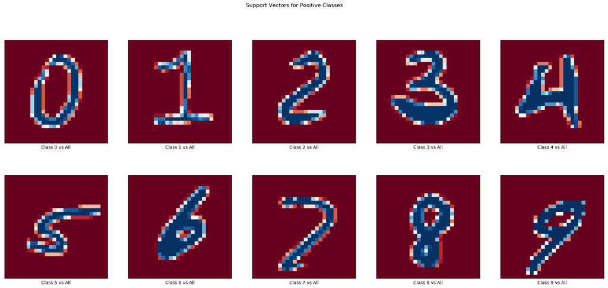

```python
ind = 0
matplot.subplots(2,5, figsize=(24,10))
for i in range(len(n_supp[15])):
    l1 = matplot.subplot(2, 5, i + 1)
    sv_image = train_samp[sup_vec[15][ind:ind+n_supp[15][i]]][0]
    l1.imshow(sv_image.reshape(28, 28), cmap=matplot.cm.RdBu)
    l1.set_xticks(())
    l1.set_yticks(())
    l1.set_xlabel('Class %i vs All' % i)
    ind = ind + n_supp[15][i]
matplot.suptitle('Support Vectors for Positive Classes')
matplot.show()
```

### Sampling one negative support vector for each class

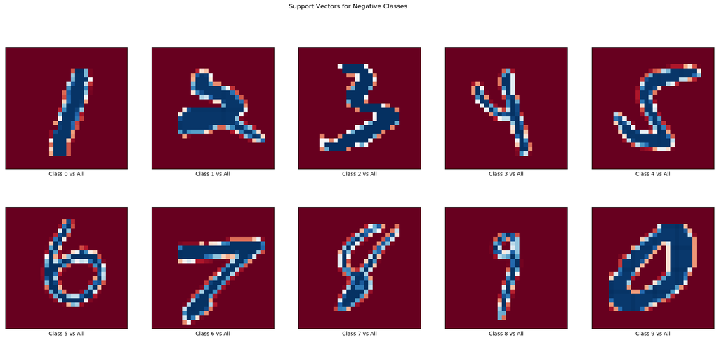

```python
ind = n_supp[15][0]
matplot.subplots(2,5, figsize=(24,10))
for i in range(len(n_supp[15])-1):
    l1 = matplot.subplot(2, 5, i + 1)
    sv_image = train_samp[sup_vec[15][ind:ind+n_supp[15][i+1]]][100]
    l1.imshow(sv_image.reshape(28, 28), cmap=matplot.cm.RdBu)
    l1.set_xticks(())
    l1.set_yticks(())
    l1.set_xlabel('Class %i vs All' % i)
    ind = ind + n_supp[15][i+1]
ind = 0
l1 = matplot.subplot(2, 5, 10)
sv_image = train_samp[sup_vec[15][ind:ind+n_supp[15][0]]][100]
l1.imshow(sv_image.reshape(28, 28), cmap=matplot.cm.RdBu)
l1.set_xticks(())
l1.set_yticks(())
l1.set_xlabel('Class 9 vs All')
matplot.suptitle('Support Vectors for Negative Classes')
matplot.show()
```

#### We can clearly interpret that the SVs in positive class are clearly distinguishable, while the SVs on the negative class show a clear difference from the class they are in, say for eg, one SV negative class 9 vs All looks no where near as a 9, which makes it better at classifying that particular class i.e. 9 in this case.

### SVC Poly kernel

```python
from scipy.stats import mode
import numpy as np
from time import time
import pandas as pd
import os
import matplotlib.pyplot as matplot
import matplotlib
%matplotlib inline

import random
matplot.rcdefaults()
from IPython.display import display, HTML
from itertools import chain
from sklearn.metrics import confusion_matrix
from sklearn.metrics import accuracy_score
import seaborn as sb
from sklearn.model_selection import ParameterGrid
from sklearn.svm import SVC, LinearSVC
import warnings
warnings.filterwarnings('ignore')
```

```python
from tensorflow.examples.tutorials.mnist import input_data
mnist = input_data.read_data_sets('MNIST_data/')
```

```
Extracting MNIST_data/train-images-idx3-ubyte.gz
Extracting MNIST_data/train-labels-idx1-ubyte.gz
Extracting MNIST_data/t10k-images-idx3-ubyte.gz
Extracting MNIST_data/t10k-labels-idx1-ubyte.gz
```

```python
train = mnist.train.images
validation = mnist.validation.images
test = mnist.test.images

trlab = mnist.train.labels
vallab = mnist.validation.labels
tslab = mnist.test.labels

train = np.concatenate((train, validation), axis=0)
trlab = np.concatenate((trlab, vallab), axis=0)
```

```python
#generating a random sequence for sampling
seq = np.random.randint(0,60000,6000)
train_samp = train[seq]
trlab_samp = trlab[seq]

train_samp.shape
trlab_samp.shape
```

```
(6000,)
```

```python
seq = np.random.randint(0,10000,1000)
test_samp = test[seq]
tslab_samp = tslab[seq]

test_samp.shape
tslab_samp.shape
```

```
(1000,)
```

## (iii)

### Running SVC for multiple cost factor(s) C and Degree

```python
coefficient = []
n_supp = []
sup_vec = []
i = 0
df = pd.DataFrame(columns = ['c','degree','train_acc','test_acc'])
for c in [0.01, 0.1, 1, 10, 100]:
    for d in [2,3,4,5,6]:
        svm = SVC(kernel='poly', C=c, degree=d)
        model = svm.fit(train_samp, trlab_samp)
        globals()['model%s' % i] = model
        d_coef = svm.dual_coef_
        support = svm.n_support_
        sv = svm.support_

        p_tr = svm.predict(train_samp)
        a_tr = accuracy_score(trlab_samp, p_tr)

        pred = svm.predict(test_samp)
        a = accuracy_score(tslab_samp, pred)

        coefficient.append(d_coef)
        n_supp.append(support)
        sup_vec.append(sv)
        df.loc[i] = [c,d,a_tr,a]
        i=i+1
```

```python
df
```

|  | c | degree | train_acc | test_acc |
| --- | --- | --- | --- | --- |
| 0 | 0.01 | 2.0 | 0.114167 | 0.116 |
| 1 | 0.01 | 3.0 | 0.114167 | 0.116 |
| 2 | 0.01 | 4.0 | 0.114167 | 0.116 |
| 3 | 0.01 | 5.0 | 0.114167 | 0.116 |
| 4 | 0.01 | 6.0 | 0.114167 | 0.116 |
| 5 | 0.10 | 2.0 | 0.118000 | 0.122 |
| 6 | 0.10 | 3.0 | 0.114167 | 0.116 |
| 7 | 0.10 | 4.0 | 0.114167 | 0.116 |
| 8 | 0.10 | 5.0 | 0.114167 | 0.116 |
| 9 | 0.10 | 6.0 | 0.114167 | 0.116 |
| 10 | 1.00 | 2.0 | 0.658333 | 0.668 |
| 11 | 1.00 | 3.0 | 0.131667 | 0.131 |
| 12 | 1.00 | 4.0 | 0.114167 | 0.116 |
| 13 | 1.00 | 5.0 | 0.114167 | 0.116 |
| 14 | 1.00 | 6.0 | 0.114167 | 0.116 |
| 15 | 10.00 | 2.0 | 0.922667 | 0.907 |
| 16 | 10.00 | 3.0 | 0.546833 | 0.555 |
| 17 | 10.00 | 4.0 | 0.136500 | 0.140 |
| 18 | 10.00 | 5.0 | 0.114167 | 0.116 |
| 19 | 10.00 | 6.0 | 0.114167 | 0.116 |
| 20 | 100.00 | 2.0 | 0.981333 | 0.945 |
| 21 | 100.00 | 3.0 | 0.889167 | 0.864 |
| 22 | 100.00 | 4.0 | 0.455667 | 0.448 |
| 23 | 100.00 | 5.0 | 0.146167 | 0.149 |
| 24 | 100.00 | 6.0 | 0.115333 | 0.116 |

We also see that the polynomial kernel behaves very wierdly, the reason being, change in cost and degree effects the entire polynomial hyperplane rather than localised hyperplane which is the case in rbf kernel, hence poly kernel is less stable than rbf.

### We choose C=100 and Degree=2 to look at the Support vectors

```python
pd.DataFrame(coefficient[20]) # dual_coef_
```

|  | 0 | 1 | 2 | 3 | 4 | 5 | 6 | 7 | 8 | 9 | ... | 3682 | 3683 | 3684 | 3685 | 3686 | 3687 | 3688 | 3689 | 3690 | 3691 |
| --- | --- | --- | --- | --- | --- | --- | --- | --- | --- | --- | --- | --- | --- | --- | --- | --- | --- | --- | --- | --- | --- |
| 0 | 10.0 | 0.0 | 10.0 | 0.000000 | 0.0 | 0.000000 | 10.0 | 0.000000 | 10.000000 | 10.0 | ... | -0.000000 | -0.0 | -0.000000 | -10.000000 | -10.0 | -0.0 | -0.00000 | -2.879215 | -0.000000 | -10.0 |
| 1 | 10.0 | 10.0 | 10.0 | 4.625618 | 0.0 | 0.000000 | 10.0 | 0.000000 | 5.846203 | 10.0 | ... | -10.000000 | -0.0 | -0.000000 | -0.000000 | -10.0 | -0.0 | -0.00000 | -0.000000 | -0.000000 | -0.0 |
| 2 | 10.0 | 0.0 | 10.0 | 10.000000 | 0.0 | 2.985243 | 10.0 | 0.000000 | 0.000000 | 10.0 | ... | -2.875142 | -0.0 | -10.000000 | -10.000000 | -10.0 | -0.0 | -0.00000 | -0.000000 | -0.000000 | -10.0 |
| 3 | 10.0 | 0.0 | 10.0 | 10.000000 | 0.0 | 0.000000 | 10.0 | 0.000000 | 10.000000 | 10.0 | ... | -10.000000 | -0.0 | -0.000000 | -0.000000 | -10.0 | -0.0 | -0.00000 | -10.000000 | -0.000000 | -0.0 |
| 4 | 10.0 | 10.0 | 10.0 | 10.000000 | 10.0 | 10.000000 | 10.0 | 0.000000 | 10.000000 | 10.0 | ... | -10.000000 | -0.0 | -10.000000 | -10.000000 | -10.0 | -10.0 | -10.00000 | -10.000000 | -0.000000 | -10.0 |
| 5 | 10.0 | 0.0 | 10.0 | 10.000000 | 0.0 | 0.000000 | 10.0 | 0.000000 | 10.000000 | 10.0 | ... | -10.000000 | -10.0 | -0.000000 | -8.748646 | -10.0 | -0.0 | -0.00000 | -10.000000 | -0.000000 | -0.0 |
| 6 | 10.0 | 0.0 | 10.0 | 10.000000 | 0.0 | 10.000000 | 10.0 | 6.083243 | 10.000000 | 10.0 | ... | -4.797141 | -0.0 | -5.501533 | -8.288558 | -10.0 | -0.0 | -0.00000 | -0.000000 | -0.000000 | -10.0 |
| 7 | 10.0 | 10.0 | 10.0 | 10.000000 | 0.0 | 10.000000 | 10.0 | 0.000000 | 0.000000 | 10.0 | ... | -10.000000 | -0.0 | -10.000000 | -10.000000 | -10.0 | -10.0 | -6.64933 | -10.000000 | -2.200562 | -10.0 |
| 8 | 10.0 | 0.0 | 10.0 | 10.000000 | 0.0 | 10.000000 | 10.0 | 1.573163 | 10.000000 | 10.0 | ... | -10.000000 | -10.0 | -0.000000 | -0.000000 | -10.0 | -0.0 | -0.00000 | -10.000000 | -0.000000 | -10.0 |

9 rows × 3692 columns

```python
pd.DataFrame(n_supp[20]) # n_support_
```

|  | 0 |
| --- | --- |
| 0 | 246 |
| 1 | 321 |
| 2 | 366 |
| 3 | 399 |
| 4 | 437 |
| 5 | 431 |
| 6 | 294 |
| 7 | 383 |
| 8 | 388 |
| 9 | 427 |

### Sampling one positive support vector for each class

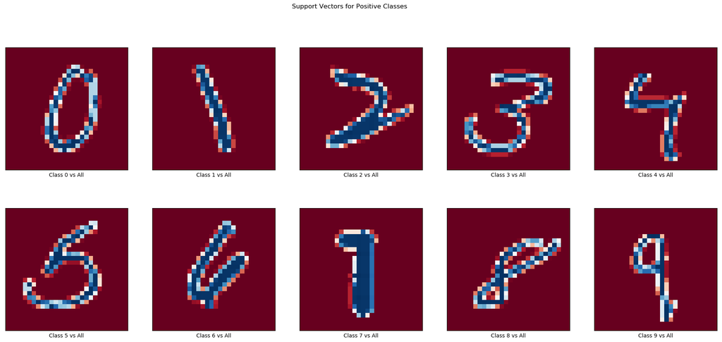

```python
ind = 0
matplot.subplots(2,5, figsize=(24,10))
for i in range(len(n_supp[20])):
    l1 = matplot.subplot(2, 5, i + 1)
    sv_image = train_samp[sup_vec[20][ind:ind+n_supp[20][i]]][0]
    l1.imshow(sv_image.reshape(28, 28), cmap=matplot.cm.RdBu)
    l1.set_xticks(())
    l1.set_yticks(())
    l1.set_xlabel('Class %i vs All' % i)
    ind = ind + n_supp[20][i]
matplot.suptitle('Support Vectors for Positive Classes')
matplot.show()
```

### Sampling one negative support vector for each class

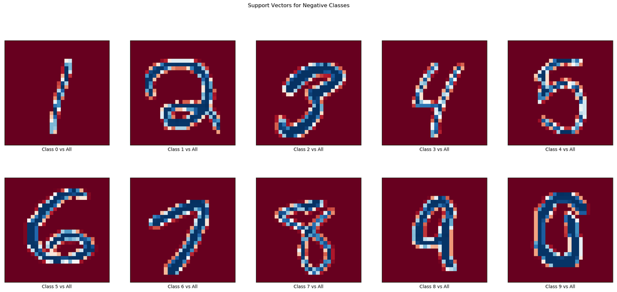

```python
ind = n_supp[20][0]
matplot.subplots(2,5, figsize=(24,10))
for i in range(len(n_supp[20])-1):
    l1 = matplot.subplot(2, 5, i + 1)
    sv_image = train_samp[sup_vec[20][ind:ind+n_supp[20][i+1]]][100]
    l1.imshow(sv_image.reshape(28, 28), cmap=matplot.cm.RdBu)
    l1.set_xticks(())
    l1.set_yticks(())
    l1.set_xlabel('Class %i vs All' % i)
    ind = ind + n_supp[20][i+1]
ind = 0
l1 = matplot.subplot(2, 5, 10)
sv_image = train_samp[sup_vec[20][ind:ind+n_supp[20][0]]][100]
l1.imshow(sv_image.reshape(28, 28), cmap=matplot.cm.RdBu)
l1.set_xticks(())
l1.set_yticks(())
l1.set_xlabel('Class 9 vs All')
matplot.suptitle('Support Vectors for Negative Classes')
matplot.show()
```

#### We can clearly interpret that the SVs in positive class are clearly distinguishable, while the SVs on the negative class show a clear difference from the class they are in, say for eg, one SV negative class 9 vs All looks no where near as a 9, which makes it better at classifying that particular class i.e. 9 in this case.

### To Summarize the Model Performance (test accuracy):

Linear SVC (best performance): 92 %  
SVC rbf (best performance): **96.4 %**  
SVC poly (best performance): 94.5 %  
Logistic regression (prev assignment): 89 %  
Naive Bayes (prev assignment): 81 %

It is clear that SVM with 'rbf' kernel gives the best result among all these models.

#### -------------------------- X --------------------------